# Practical Machine Learning Course Project

Mahamane Sani Ibrahim

23/11/2020

# Background

Using devices such as Jawbone Up, Nike FuelBand, and Fitbit it is now possible to collect a large amount of data about personal activity relatively inexpensively. These type of devices are part of the quantified self movement – a group of enthusiasts who take measurements about themselves regularly to improve their health, to find patterns in their behavior, or because they are tech geeks. One thing that people regularly do is quantify how much of a particular activity they do, but they rarely quantify how well they do it. In this project, we will use data from accelerometers on the belt, forearm, arm and dumbell of 6 participants to predict the manner in which they did the exercise.

# Data cleansing and Exploratory data analysis

```r
dim(Training)
```

```
## [1] 19622   160
```

```r
dim(Testing)
```

```
## [1]  20 160
```

```r
# Delete columns with all missing values
Training<-Training[,colSums(is.na(Training)) == 0]
Testing <-Testing[,colSums(is.na(Testing)) == 0]
# Delete variables are irrelevant to our current project: user_name, raw_timestamp_part_1, raw_timestamp_part_,2 cvtd_timestamp, new_window, and  num_window (columns 1 to 7).
Training   <-Training[,-c(1:7)]
Testing <-Testing[,-c(1:7)]
Training$classe<-as.factor(Training$classe)
# partition the data so that 75% of the Training dataset into Training and the remaining 25% to Testing
traintrainset <- createDataPartition(y=Training$classe, p=0.75, list=FALSE)
TrainTraining <- Training[traintrainset, ]
TestTraining <- Training[-traintrainset, ]
dim(Training)
```

```
## [1] 19622    53
```

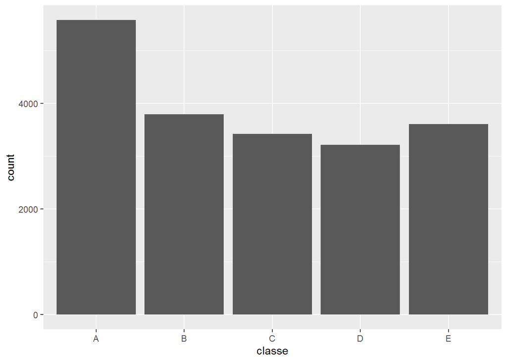

```r
ggplot(Training)+aes(x = classe)+stat_count()
```

# Prediction using decision tree

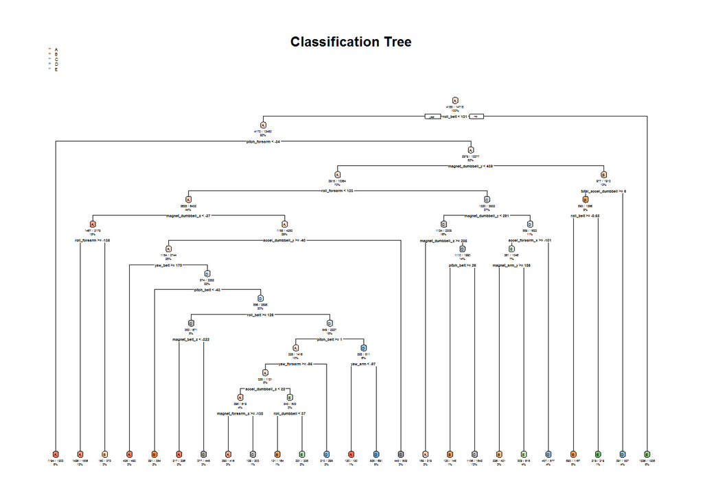

```r
model1 <- rpart(classe ~ ., data=TrainTraining, method="class")
# Predicting:
predict1 <- predict(model1, TestTraining, type = "class")
# Plot of the Decision Tree
rpart.plot(model1, main="Classification Tree", extra=102, under=TRUE, faclen=0)
```

```r
# Test results on our TestTraining data set:
confusionMatrix(predict1, TestTraining$classe)
```

```
## Confusion Matrix and Statistics
##
##           Reference
## Prediction    A    B    C    D    E
##          A 1273  132   19   51   35
##          B   51  615   64   63   79
##          C   25   77  700  113   97
##          D   18   75   53  522   63
##          E   28   50   19   55  627
##
## Overall Statistics
##
##                Accuracy : 0.762
##                  95% CI : (0.7499, 0.7739)
##     No Information Rate : 0.2845
##     P-Value [Acc > NIR] : < 2.2e-16
##
##                   Kappa : 0.6982
##
##  Mcnemar's Test P-Value : < 2.2e-16
##
## Statistics by Class:
##
##                      Class: A Class: B Class: C Class: D Class: E
## Sensitivity            0.9125   0.6481   0.8187   0.6493   0.6959
## Specificity            0.9325   0.9350   0.9229   0.9490   0.9620
## Pos Pred Value         0.8430   0.7053   0.6917   0.7141   0.8049
## Neg Pred Value         0.9641   0.9172   0.9602   0.9324   0.9336
## Prevalence             0.2845   0.1935   0.1743   0.1639   0.1837
## Detection Rate         0.2596   0.1254   0.1427   0.1064   0.1279
## Detection Prevalence   0.3079   0.1778   0.2064   0.1491   0.1588
## Balanced Accuracy      0.9225   0.7915   0.8708   0.7991   0.8290
```

# Prediction using random forest

```r
model2 <- randomForest(classe ~. , data=TrainTraining, method="class")

# Predicting:
predict2 <- predict(model2, TestTraining, type = "class")

# Test results on TestTrainingSet data set:
confusionMatrix(predict2, TestTraining$classe)
```

```
## Confusion Matrix and Statistics
##
##           Reference
## Prediction    A    B    C    D    E
##          A 1394    3    0    0    0
##          B    1  945    5    0    0
##          C    0    1  848    6    3
##          D    0    0    2  797    3
##          E    0    0    0    1  895
##
## Overall Statistics
##
##                Accuracy : 0.9949
##                  95% CI : (0.9925, 0.9967)
##     No Information Rate : 0.2845
##     P-Value [Acc > NIR] : < 2.2e-16
##
##                   Kappa : 0.9936
##
##  Mcnemar's Test P-Value : NA
##
## Statistics by Class:
##
##                      Class: A Class: B Class: C Class: D Class: E
## Sensitivity            0.9993   0.9958   0.9918   0.9913   0.9933
## Specificity            0.9991   0.9985   0.9975   0.9988   0.9998
## Pos Pred Value         0.9979   0.9937   0.9883   0.9938   0.9989
## Neg Pred Value         0.9997   0.9990   0.9983   0.9983   0.9985
## Prevalence             0.2845   0.1935   0.1743   0.1639   0.1837
## Detection Rate         0.2843   0.1927   0.1729   0.1625   0.1825
## Detection Prevalence   0.2849   0.1939   0.1750   0.1635   0.1827
## Balanced Accuracy      0.9992   0.9971   0.9947   0.9950   0.9965
```

# Conclusion

The Random Forest algorithm performed better than Decision Trees. It’s accuracy was 0.995 (95% CI: (0.9925, 0.9967)) compared to Decision Tree model with 0.762 (95% CI: (0.7499, 0.7739)). So, we chose the Random Forests model. The expected out-of-sample error is estimated at 0.005, or 0.5%.

## Final prediction

Below, we show the result of the final prediction

```r
predictfinal <- predict(model2, Testing, type="class")
predictfinal
```

```
##  1  2  3  4  5  6  7  8  9 10 11 12 13 14 15 16 17 18 19 20
##  B  A  B  A  A  E  D  B  A  A  B  C  B  A  E  E  A  B  B  B
## Levels: A B C D E
```